# Strava API!

I'm following this [tutorial](https://towardsdatascience.com/using-the-strava-api-and-pandas-to-explore-your-activity-data-d94901d9bfde), I have been wanting to do a project with my strava data for a while, and I finally got a free weekend! I originally learned how to use Postman API with a short course, which was nice since I had to use it for this tutorial and already knew the ropes. I would like to integrate this into my personal website at some point, but step by step...

```python
# Importing libraries
import requests
import urllib3
import pandas as pd
import json
import numpy as np
from datetime import datetime
import matplotlib.pyplot as plt
import matplotlib.dates as dates
import seaborn as sns


urllib3.disable_warnings(urllib3.exceptions.InsecureRequestWarning)
```

```python
auth_url = "https://www.strava.com/oauth/token"
activites_url = "https://www.strava.com/api/v3/athlete/activities"

# Previously did json.dump() so I don't leak my api creds lol
with open("Strava-Creds.json", "r") as f:
    payload = f.read()

# This converts it from the read str type to dict
payload = json.loads(payload)
```

```python
print("Requesting Token...\n")
res = requests.post(auth_url, data=payload, verify=False)
access_token = res.json()["access_token"]

header = {"Authorization": "Bearer " + access_token}
param = {"per_page": 200, "page": 1}
my_dataset = requests.get(activites_url, headers=header, params=param).json()

activities = pd.json_normalize(my_dataset)

print(activities.head())
```

```
Requesting Token...

   resource_state                                               name  \
0               2                                 Lauf am Nachmittag
1               2                                      Lauf am Abend
2               2                                     Lauf am Morgen
3               2  Rainbow Valley, Dysart and Toothaker Trail Loo...
4               2                                     Half Marathon!

   distance  moving_time  elapsed_time  total_elevation_gain type sport_type  \
0    6711.5         2530          2934                  17.9  Run        Run
1    4977.4         1760          2011                  19.4  Run        Run
2    3817.7         1737          1994                   3.3  Run        Run
3    7837.2         3047          3120                  97.6  Run        Run
4   21423.6         7194          7207                  45.9  Run        Run

   workout_type           id  ... pr_count total_photo_count has_kudoed  \
0           0.0  10155838221  ...        0                 0      False
1           0.0  10111307912  ...        1                 0      False
2           0.0  10086182111  ...        0                 0      False
3           0.0  10079227309  ...        0                 0      False
4           0.0  10044548704  ...        2                 0      False

   athlete.id athlete.resource_state        map.id  \
0    16884270                      1  a10155838221
1    16884270                      1  a10111307912
2    16884270                      1  a10086182111
3    16884270                      1  a10079227309
4    16884270                      1  a10044548704

                                map.summary_polyline  map.resource_state  \
0  yogbEnvhdTJIDKJw@l@w@Vc@t@m@JYd@kB`@sB^cBFKDSZ...                   2
1  }awcEzpgdTCkB@U@AG{@FSCOEqBBMCS?gAGk@D[Gi@?U@Q...                   2
2  ymhkEzwilTBD?FFHEJ?PDP?zDBJA^Dh@ANLFHVAZBn@ARB...                   2
3  a_ujEvu{lT?HKZg@f@UNu@HMNEPBn@Qr@?r@HJRFFLJ|@H...                   2
4  wm~cEfs~cTPc@zDkGdAEdAHhBCPtCDnCIbH[jH[hCm@bDc...                   2

   average_heartrate  max_heartrate
0                NaN            NaN
1                NaN            NaN
2              129.5          157.0
3              169.2          184.0
4              168.1          189.0

[5 rows x 52 columns]
```

```python
# Separating out the interesting data from the rest
ich_will_diese = [
    "name",
    "distance",
    "moving_time",
    "elapsed_time",
    "total_elevation_gain",
    "type",
    "upload_id",
    "start_date_local",
    "timezone",
    "athlete_count",
    "average_speed",
    "max_speed",
    "average_heartrate",
    "max_heartrate",
]

cool_data = activities[ich_will_diese]
```

```python
to_datetime = pd.to_datetime(activities["start_date_local"])
cool_data.loc[:, "start_datetime_local"] = to_datetime

distance = cool_data["distance"] / (1000 * 1.609)
cool_data.loc[:, "distance"] = distance

hours = cool_data["start_datetime_local"].dt.hour + (cool_data["start_datetime_local"].dt.minute / 60)

hours = round(hours, 3)
```

Now that all the data is organized, I'm curious about some things! First thing, I want to see how the time of my runs and the length of my runs trends (or is there one?)

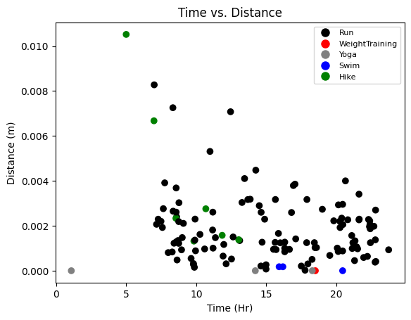

```python
# Doing thing for coloring according to exercise type, tbh this is so much easier in R :(
activity_colors = {
    "Run": "black",
    "WeightTraining": "red",
    "Yoga": "grey",
    "Swim": "blue",
    "Hike": "green",
}


fig, ax = plt.subplots()

scatter = ax.scatter(
    hours,
    cool_data["distance"],
    color=[activity_colors[i] for i in cool_data["type"]],
)

# Create handles for legend
legend_handles = []
for activity, color in activity_colors.items():
    legend_handles.append(
        plt.Line2D(
            [0],
            [0],
            marker="o",
            color="w",
            markerfacecolor=color,
            markersize=10,
            label=activity,
        )
    )

# Set legend
ax.legend(handles=legend_handles, fontsize=8)


# Labelling
plt.title("Time vs. Distance")
plt.xlabel("Time (Hr)")
plt.ylabel("Distance (m)")


# if the run is over 10 miles, then it gets a label!
for i, run in enumerate(cool_data["distance"]):
    if run > 10:
        ax.text(
            hours[i],
            cool_data.at[i, "distance"],
            cool_data.at[i, "name"],
            fontsize=8,
            ha="right",
        )

plt.show()
```

Now I would like to see if there is any trend between the length of my runs and the time of day! I don't see any real trend, besides the outlier days when I did something really wild, which meant that I had to get up early to do it.

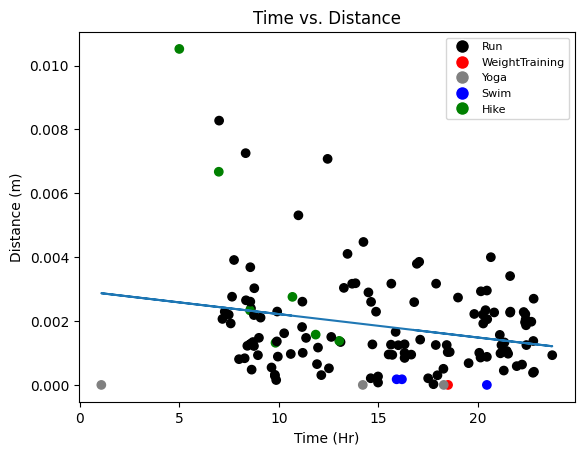

```python
a, b = np.polyfit(hours, cool_data["distance"], 1)


fig, ax = plt.subplots()

scatter = ax.scatter(
    hours,
    cool_data["distance"],
    color=[activity_colors[i] for i in cool_data["type"]],
)
# Create handles for legend
legend_handles = []
for activity, color in activity_colors.items():
    legend_handles.append(
        plt.Line2D(
            [0],
            [0],
            marker="o",
            color="w",
            markerfacecolor=color,
            markersize=10,
            label=activity,
        )
    )

# Set legend
ax.legend(handles=legend_handles, fontsize=8)
ax.plot(hours, a*hours+b)

# Labelling
plt.title("Time vs. Distance")
plt.xlabel("Time (Hr)")
plt.ylabel("Distance (m)")

plt.show()
```

Now checking if my speed has increased over time!

```python
runs = cool_data.loc[cool_data["type"] == "Run"]

runs_filtered = runs.loc[runs["average_speed"] < 6]
```

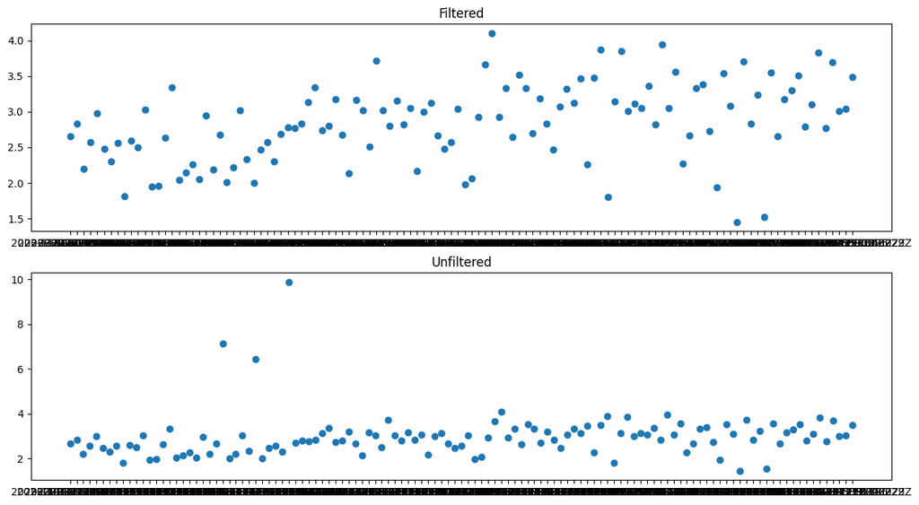

```python
fig, (ax1, ax2) = plt.subplots(2, figsize=(15,8))

day = range(len(runs_filtered.start_date_local))
x = np.asarray(runs_filtered.start_date_local)  #convert data to numpy array
y = np.asarray(runs_filtered.average_speed)

x_unfiltered = np.asarray(runs.start_date_local)
y_unfiltered = np.asarray(runs.average_speed)
ax1.set_title("Filtered")
ax2.set_title("Unfiltered")

ax1.plot_date(x, y) #plot data points in scatter plot on ax1
ax2.plot_date(x_unfiltered, y_unfiltered) #plot data points in scatter plot on ax1


plt.show()
```

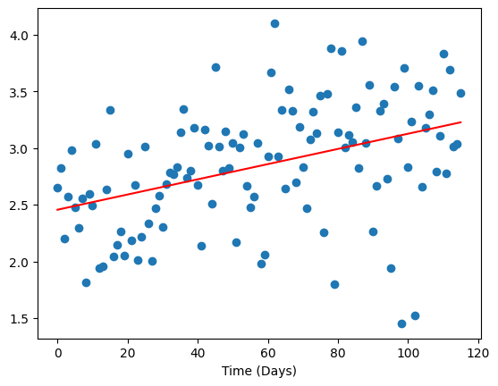

```
0.006705328105178195 2.455883289124667
```

```python
a, b = np.polyfit(day, runs_filtered["average_speed"], 1)

plt.scatter(day, y) #plot data points in scatter plot on ax1
plt.plot(day, a*day+b, color="red")
plt.xlabel("Time (Days)")
plt.show()

print(a,b)
```